# 第5回 正則化による多重共線性の問題への対処

## 前回からの接続

第4回は、銀河の5色の明るさから赤方偏移を当てる式を作り、交差検証（cross-validation）で確かめました。5色の等級をそのまま入れると、相関の強い列どうしで係数が揺れて読めませんでした（多重共線性）。そこで、隣り合う色の差に作り直して、係数を読める式にしました。

でも、いつも作り直し方が分かるとは限りません。今日の列は100本で、似た列がたくさんあります。列がたくさんあるときに、当たりを保ちながら、係数を落ち着かせられるでしょうか。

## 今日の分析目標

光の吸収スペクトルから、肉の脂肪はどこまで分かるかに答える。

ひき肉に近赤外の光を当てて測ったスペクトル（100本の波長の吸収）から、脂肪の割合を当てる式を作ります。係数にペナルティをかけて縮める正則化で、当たりを良くし、係数を落ち着かせます。そして、どの波長が脂肪を教えているかを選び出します。

もう1つのねらいは、くり返しの結果を辞書にため、名前で引けるようになることです。ペナルティの強さαごとのMAEや、波長ごとに選ばれた回数を、名前つきでためます。

### 公開データの世界

第4回は、宇宙のデータベースSDSSで、銀河の5色の明るさを使いました。今日は、食品の分析のデータです。データの形も、くせも違います。同じ道具を、そのデータに合わせて組み立て直すのが、データサイエンスの醍醐味です。

### 場面

店の「糖度12度以上」のみかんは、選果場で1個ずつ甘さを測っています。光を当て、実を通り抜けた光から糖度を当てるので、切らずに全部の実を測れます（光センサー選果機）。

今日のデータは、ひき肉です。ひき肉の原料は、脂肪の割合で値段が変わり、赤身が多いほど高く売れます。脂肪の上限も決まっていて、たとえばEUの規則では、赤身ひき肉は7%以下、牛ひき肉は20%以下です。工場は、脂の多い肉と赤身の肉を混ぜて、狙いの割合に合わせます。

脂肪の割合を正確に測るには、溶剤で脂を溶かし出して重さを量る化学分析をします。ただ、1回に数時間かかり、測った肉は捨てることになります。工場には毎日たくさんの肉が流れてくるので、その場で、壊さずに測りたいのです。

そこで、肉に近赤外の光を当て、通り抜けた光を色（波長）ごとに測ります。波長ごとに、光がどれだけ吸われたかが分かります。脂肪や水は、それぞれ決まった波長の光をよく吸うので、この吸収の曲線（スペクトル）には、肉の中身が表れます。この測り方を近赤外分光と呼びます。みかんの選果機も、同じ仕組みです。

化学分析した肉を手がかりに、光のスペクトルから脂肪の割合を当てる式を作りたい。一度式ができれば、あとは光だけで測れます。できれば、どの波長が脂肪を教えているかも知りたい。

ただし、式を作るには、光と化学分析の両方で測った肉が要ります。化学分析は高くて遅いので、そういう肉は少ししか用意できません。一方で、波長は100本あります。少ない肉で、たくさんの列を扱うことになります。

### 手元のデータ

Tecator（テカトール）社の装置で測った、ひき肉240個のデータです。1行が1個の肉です。

- `850`〜`1048`：850〜1048nmを2nmおきに、100本の波長での吸収。光をどれだけ吸ったかの量で、大きいほどよく吸った
- 水分・脂肪・たんぱく質：化学分析で測った割合（%）

今日は「化学分析できたのは120個だけ」という場面にして、240個から120個を抜き出して使います（0節）。

データは公開（パブリックドメイン）されていて、許可文を添えれば再配布できます。結果を発表するときは、装置と会社の名前（Tecator）を書くことになっています。

### 最後に出す答え

光のスペクトルから、脂肪の割合をどれくらいの外れで当てられるか（交差検証のMAE）です。そして、どの波長が脂肪を教えているかです。

### 今日の一周（結果だけ先に）

コードの説明はあとにして、今日の解析を、結果だけで一度通して見ておきます。

1. 作って測る：100本の波長で式を作ると、脂肪は平均3.0%の外れで当たります。でも係数は、隣の波長どうしで+と−に暴れます。
2. 縮める：係数にペナルティをかける（リッジ）と、外れは1.98%に減り、係数も落ち着きます。
3. 強さを選ぶ：ペナルティの強さαを辞書にためて交差検証で比べ、α = 1を選びます。
4. 選ばせる：ラッソは数本に絞ります。でも肉を取り直すたびに、選ぶ波長が隣と入れ替わります。
5. 束で選ぶ：エラスティックネットは、隣どうしの波長を帯で残し、20回とも同じ帯になります。
6. 探し方：エラスティックネットには、αとrの2つのつまみがあります。全部の組を試すか、1つずつ動かすかで探します。えっ、残った帯の1つは930nmのまわり。脂肪が光を吸う波長として知られています。

このあと、この6つの段の中身を、1つずつ開けていきます。

### 今日の問いとやること

| 段 | 問い | やること |
| --- | --- | --- |
| 作って測る（1・2節） | 100本で当たる？ | 100本の波長で式を作り、交差検証で外れを測って、係数を描く |
| 縮める（3節） | 係数を落ち着かせられる？ | 係数にペナルティをかける式（リッジ）で、外れと係数を比べる |
| 強さを選ぶ（4節） | αはいくつ？ | αを動かし、交差検証のMAEを辞書にためて選ぶ |
| 選ばせる（5節） | 効く波長だけ残せる？ | ラッソで絞り、20回取り直して、選ばれた回数を数える |
| 束で選ぶ（6節） | 揺れずに選べる？ | エラスティックネットで帯を残し、20回取り直して数える |
| 探し方（7節） | つまみ2つをどう探す？ | αとrを、全部の組で試す方法と、1つずつ動かす方法で探す |

### 今日の進め方

段ごとに、まずスライドで、その段の結論までを通して聞きます。段の終わりにノートへ移り、その段の節のセルを上から実行して、スライドと同じ数が出るかを確かめます。そして、段ごとに1つあるTODOに答えます。

TODOは、実行の前に結果を予想して書き、1か所を替えて実行し、予想と比べる形です。予想が外れても、かまいません。

## 学習ゴール

この回を終えると、次のことができるようになります。

- 列が多く、似た列がたくさんあると、係数が暴れて読めなくなることを、係数の図と組ごとの係数で確かめられる
- 係数にペナルティをかけて縮める（正則化）ことで、当たりが良くなり、係数が落ち着くことを説明できる
- ペナルティの強さαを、候補を並べて交差検証で選べる（チューニング）
- つまみが2つのとき、全部の組を試す（グリッドサーチ）方法と、1つずつ動かす（貪欲法）方法で探し、回数と結果を比べられる
- リッジ・ラッソ・エラスティックネットの違い（縮める・0にして選ぶ・束で選ぶ）を説明できる
- ラッソの選んだ列が、データを取り直すと入れ替わることを確かめ、その理由を説明できる
- 結果を辞書にため、名前（キー）で引ける

## 0. 準備

### 最初に実行する：道具を呼び出す

- 役割：このノートで使う道具（ライブラリ）を呼び出す
- 入力：なし
- 出力：なし（終わるとセルの左に ✓ が付く）

`Ridge`・`Lasso`・`ElasticNet`は、今日使う3つの「ペナルティをかけた線形回帰（linear regression）」です。中身は3節から順に説明します。

```python
import numpy as np
import pandas as pd
import matplotlib.pyplot as plt
from sklearn.linear_model import LinearRegression, Ridge, Lasso, ElasticNet
```

### 図の日本語を表示できるようにする

- 役割：図の中の日本語が □ にならないようにし、図の大きさと字の大きさをそろえる
- 入力：なし
- 出力：「セットアップ完了」の表示

`try:`から先は、日本語表示の道具が動かなくなったときの保険で、中身は読まなくてかまいません。

```python
# 日本語が図の中で □ になるのを防ぐ
!pip install -q japanize-matplotlib
try:
    import japanize_matplotlib
# japanize が動かなくなったときの保険：同梱フォントを直接登録する
except Exception:
    from importlib.util import find_spec
    from matplotlib import font_manager as fm
    from pathlib import Path
    spec = find_spec('japanize_matplotlib')
    ttf = None
    if spec:
        ttf = next(Path(spec.origin).parent.rglob('*.ttf'), None)
    if ttf:
        fm.fontManager.addfont(str(ttf))
        name = fm.FontProperties(fname=str(ttf)).get_name()
        plt.rcParams['font.family'] = name

plt.rcParams['figure.figsize'] = (9, 5)
plt.rcParams['font.size'] = 13
plt.rcParams['axes.unicode_minus'] = False  # マイナス記号の化けを防ぐ
print('セットアップ完了')
```

```
セットアップ完了
```

### お手本：表を読み込む

- 役割：肉の表を読み込み、答えの列の名前を日本語にして、先頭5行を見る
- 入力：データの置き場所`DATA_DIR`と、ファイル名`tecator.csv`
- 出力：表`raw`（240個の肉）

吸収の100本の列は、波長の数（`850`〜`1048`）を名前にしています。答えの3列は、`rename`に辞書`{'元の名前': '新しい名前'}`を渡して、日本語に付け替えます（第1回の書き方です）。

```python
# データはこのリポジトリから読み込む
DATA_DIR = ('https://raw.githubusercontent.com/k0heiun0/'
            'applied_exercise_preview/main/shared/data')
raw = pd.read_csv(f'{DATA_DIR}/tecator.csv')
raw = raw.rename(columns={'moisture': '水分', 'fat': '脂肪', 'protein': 'たんぱく質'})
print(len(raw), '個')
raw.head()
```

```
240 個
```

|  | 850 | 852 | 854 | 856 | 858 | 860 | 862 | 864 | 866 | 868 | ... | 1036 | 1038 | 1040 | 1042 | 1044 | 1046 | 1048 | 水分 | 脂肪 | たんぱく質 |
| --- | --- | --- | --- | --- | --- | --- | --- | --- | --- | --- | --- | --- | --- | --- | --- | --- | --- | --- | --- | --- | --- |
| 0 | 2.61776 | 2.61814 | 2.61859 | 2.61912 | 2.61981 | 2.62071 | 2.62186 | 2.62334 | 2.62511 | 2.62722 | ... | 2.94013 | 2.91978 | 2.89966 | 2.87964 | 2.85960 | 2.83940 | 2.81920 | 60.5 | 22.5 | 16.7 |
| 1 | 2.83454 | 2.83871 | 2.84283 | 2.84705 | 2.85138 | 2.85587 | 2.86060 | 2.86566 | 2.87093 | 2.87661 | ... | 3.26655 | 3.25369 | 3.24045 | 3.22659 | 3.21181 | 3.19600 | 3.17942 | 46.0 | 40.1 | 13.5 |
| 2 | 2.58284 | 2.58458 | 2.58629 | 2.58808 | 2.58996 | 2.59192 | 2.59401 | 2.59627 | 2.59873 | 2.60131 | ... | 2.65112 | 2.63262 | 2.61461 | 2.59718 | 2.58034 | 2.56404 | 2.54816 | 71.0 | 8.4 | 20.5 |
| 3 | 2.82286 | 2.82460 | 2.82630 | 2.82814 | 2.83001 | 2.83192 | 2.83392 | 2.83606 | 2.83842 | 2.84097 | ... | 2.92576 | 2.90251 | 2.87988 | 2.85794 | 2.83672 | 2.81617 | 2.79622 | 72.8 | 5.9 | 20.7 |
| 4 | 2.78813 | 2.78989 | 2.79167 | 2.79350 | 2.79538 | 2.79746 | 2.79984 | 2.80254 | 2.80553 | 2.80890 | ... | 3.25831 | 3.23784 | 3.21765 | 3.19766 | 3.17770 | 3.15770 | 3.13753 | 58.3 | 25.5 | 15.5 |

5 rows × 103 columns

列が100本並びます。1行の100個の数を、波長の順に並べると、1本の曲線（スペクトル）になります。

### お手本：化学分析できた120個を抜き出す

- 役割：波長の列の名前を`waves`に、波長の数を`nm`にしまい、吸収を1000倍してから、240個から120個を抜き出す
- 入力：表`raw`
- 出力：表`df`（120個）と、脂肪の割合の要約

`raw.columns[:100]`は、列の名前のうち先頭の100本です。`range(850, 1050, 2)`は、850から2ずつ増やして1050の手前までの数（850, 852, …, 1048）で、図の横軸に使います。吸収は1000倍して、ミリ吸光度という単位にします（分光でよく使う単位です。あとでペナルティの強さαを、読みやすい数で書くためです）。`sample(120, random_state=0)`は、行を120個、くじで選びます。

**書き方メモ（読み飛ばしてよい）**

`reset_index(drop=True)`は、抜き出した行に、0から振り直した行の番号を付けます。元の表での番号は捨てます。これで、`df`の行の番号は0〜119になります。

`raw[waves] = raw[waves] * 1000`は、100本の列をまとめて1000倍し、元の列に書き戻します。

```python
waves = list(raw.columns[:100])     # 波長の列の名前（100本）
nm = list(range(850, 1050, 2))      # 波長の数（図の横軸）
raw[waves] = raw[waves] * 1000      # ミリ吸光度に直す
df = raw.sample(120, random_state=0).reset_index(drop=True)
print(len(df), '個')
print(df['脂肪'].describe().round(1))
```

```
120 個
count    120.0
mean      18.5
std       14.9
min        2.0
25%        6.8
50%       12.2
75%       28.2
max       57.9
Name: 脂肪, dtype: float64
```

脂肪の割合は2.0〜57.9%で、中央値は12.2%、平均は18.5%です。

### お手本：スペクトルを描く

- 役割：脂肪のいちばん少ない肉と、いちばん多い肉のスペクトルを重ねて描く
- 入力：表`df`、波長の列`waves`、波長の数`nm`
- 出力：2本の曲線

`idxmin()`・`idxmax()`は、いちばん小さい・大きい値の行の番号を返します。`df.loc[行の番号, waves]`は、その行の、波長の列の100個の数です。

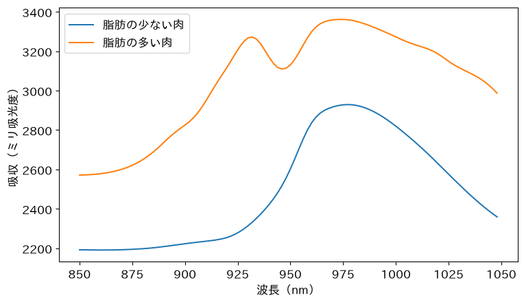

```python
lean = df['脂肪'].idxmin()
fat = df['脂肪'].idxmax()
plt.plot(nm, df.loc[lean, waves], label='脂肪の少ない肉')
plt.plot(nm, df.loc[fat, waves], label='脂肪の多い肉')
plt.xlabel('波長（nm）')
plt.ylabel('吸収（ミリ吸光度）')
plt.legend()
plt.show()
```

2つの肉で、曲線の高さも形も違います。どこの違いが脂肪を表しているのかは、今日の最後に分かります。

## 1. 100本で式を作る

ここから、段1「作って測る」（1・2節）です。問いは、100本の波長で、脂肪がどのくらい当たるか、です。

表が整いました。まず第4回と同じ手順で、式を作って交差検証で測ります。

### 式の形

$x_{i1}, \dots, x_{i,100}$が$i$番目の肉の100本の波長の吸収、$b_1, \dots, b_{100}$が係数、$\hat{y}_i$が脂肪の割合の予測です。

$$\hat{y}_i = b_0 + b_1 x_{i1} + b_2 x_{i2} + \cdots + b_{100} x_{i,100}$$

### おさらい：交差検証

肉を5つの組に分け、1つずつテストにして、5回MAEを測ります。5回のMAEを平均します。どの肉も、ちょうど1度ずつテストに入ります。2つの式は、同じ組どうしで比べます（第4回）。

### お手本：交差検証の関数

- 役割：組`k`をテスト、残りを訓練にして式を作り、5回分のMAEをリストにためて返す
- 入力：表`df`、手がかりの列の名前`cols`、式の作り方`model`
- 出力：5回分のMAEのリスト

第4回の`cv_mae`と同じ流れです。違うのは、式の作り方`model`も引数で渡すことです。`model`に`LinearRegression()`を渡せば普通の線形回帰、このあと別の作り方を渡せば、同じ物差しで比べられます。引数で渡した道具も、関数の中で`fit`と`predict`が使えます。

```python
df['組'] = df.index % 5

def cv_mae(df, cols, model):
    maes_k = []
    for k in range(5):
        tr_k = df[df['組'] != k]      # 組k以外で訓練
        te_k = df[df['組'] == k]      # 組kでテスト
        model.fit(tr_k[cols], tr_k['脂肪'])
        pred_k = model.predict(te_k[cols])
        maes_k.append(np.abs(te_k['脂肪'] - pred_k).mean())
    return maes_k
```

### お手本：100本で交差検証

- 役割：100本の波長の普通の線形回帰を、交差検証で測る。比べるために、どの肉も平均で当てたときの外れも出す
- 入力：表`df`、波長の列`waves`
- 出力：5回分のMAEと平均、平均で当てたときのMAE

```python
cv_ols = cv_mae(df, waves, LinearRegression())
print(np.round(cv_ols, 2), round(np.mean(cv_ols), 2))
base = np.abs(df['脂肪'] - df['脂肪'].mean()).mean()
print(round(base, 2))               # 平均で当てたとき
```

```
[2.55 4.35 2.92 2.99 2.18] 3.0
12.24
```

100本の波長の式では、脂肪の割合は平均3.0%の外れです。どの肉も平均の18.5%と当てると、外れは平均12.24%です。光だけで、外れを4分の1まで縮めました。

### お手本：訓練の肉では？

- 役割：組0以外の96個で式を作り、その96個（訓練）での外れを測る
- 入力：表`df`
- 出力：訓練でのMAE

```python
tr_0 = df[df['組'] != 0]
m_0 = LinearRegression().fit(tr_0[waves], tr_0['脂肪'])
err_0 = np.abs(tr_0['脂肪'] - m_0.predict(tr_0[waves]))
print(round(err_0.mean(), 2))
```

```
0.69
```

訓練の96個では外れ0.69%で、ほぼ当たっています。テストでは3.0%です。式を作った肉に合わせすぎています（第2回の過学習）。

## 2. 係数は読める？

外れ3.0%の式ができました。次は、どの波長が脂肪を教えているかを読みます。係数を、波長に沿って描いてみます。

### お手本：係数を波長に沿って描く

- 役割：120個すべてで普通の線形回帰の式を作り、100個の係数を波長の順に折れ線で描く
- 入力：表`df`、波長の列`waves`、波長の数`nm`
- 出力：係数の折れ線

`m_ols.coef_`は、100本の列の係数を、列の順に並べたものです。

```
-21.5 24.4
```

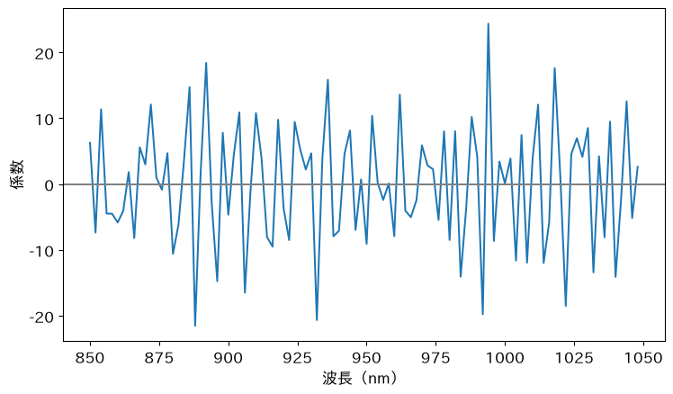

```python
m_ols = LinearRegression().fit(df[waves], df['脂肪'])
print(round(m_ols.coef_.min(), 1), round(m_ols.coef_.max(), 1))
plt.plot(nm, m_ols.coef_)
plt.axhline(0, color='gray')
plt.xlabel('波長（nm）')
plt.ylabel('係数')
plt.show()
```

係数は−21.5〜+24.4の間で、隣どうしで+と−が入れ替わります。「930nmの吸収が1増えると、脂肪が〇%増える」とは、とても読めません。

### お手本：組を替えると、930nmの係数は？

- 役割：組`k`以外で式を作り、波長`w`の係数を返す関数を作り、5つの組で930nmの係数をためる
- 入力：式の作り方`model`、組の番号`k`、波長の名前`w`
- 出力：5回分の930nmの係数

第4回の`r_coef`と同じ形です。`pd.Series(係数, index=列の名前)`で係数に名前を付け、`[w]`で波長`w`の係数を取り出します。

```python
def coef_at(model, k, w):
    tr_k = df[df['組'] != k]
    model.fit(tr_k[waves], tr_k['脂肪'])
    return pd.Series(model.coef_, index=waves)[w]

c930_ols = []
for k in range(5):
    c930_ols.append(coef_at(LinearRegression(), k, '930'))
print(np.round(c930_ols, 1))
```

```
[ -1.2  -1.3  13.9 -14.7   2.7]
```

930nmの係数は、組を替えるだけで−14.7〜+13.9と、符号まで変わります。

### お手本：隣の波長どうしの相関

- 役割：100本どうしの相関係数を出し、930nmと932nmの相関と、いちばん小さい相関を表示する
- 入力：表`df`、波長の列`waves`
- 出力：2つの相関係数

`corr()`は、列どうしの相関係数の表です。`.loc['930', '932']`で、930nmの行・932nmの列を取り出します。`.values.min()`は、表の中でいちばん小さい数です。

```python
corr = df[waves].corr()
print(round(corr.loc['930', '932'], 5))
print(round(corr.values.min(), 3))
```

```
0.99997
0.959
```

930nmと932nmの相関は0.99997で、ほとんど同じです。100本どうしの相関は、いちばん小さくても0.959です。

似た列が100本も並ぶので、式は手柄をどう分けるかを決められず、係数が揺れます。第4回で見た多重共線性（multicollinearity）が、100本で起きています。

> 重要：予測と係数は別

> 相関の強い列がたくさんあると、予測はそこそこ当たっても、係数は揺れて読めない。

### TODO①：使う波長を替える（予想 → 実行 → 比べる）

下のセルは、930nmの1本だけで当てる式を交差検証で測り、係数を表示します。

まず、予想を書いてください。930nmの1本だけで当てると、外れはどのくらいでしょうか。隣の3本（930・932・934nm）にすると、どうなるでしょうか。

（ここに予想を書く）

予想を書いたら、セルの`['930']`を`['930', '932', '934']`に替えて実行してください。

```python
# TODO: ['930'] を ['930', '932', '934'] に替えて実行する
cols_x = ['930']
print(round(np.mean(cv_mae(df, cols_x, LinearRegression())), 2))
m_x = LinearRegression().fit(df[cols_x], df['脂肪'])
print(m_x.coef_.round(1))
```

```
10.07
[0.]
```

### やってみよう：予想と比べる

実行した結果を、予想と比べてください。1本と3本で、外れはどう変わりましたか。3本の係数を見て、気づいたことを書いてください。

（ここに答えを書く）

930nmの1本だけでは10.07%で、平均で当てるのとほとんど変わりません。隣の3本にすると3.11%で、100本の式（3.0%）に近くなります。

1本の吸収の高さは、肉の厚みなどで、曲線全体ごと上下します。だから、1本だけでは脂肪を教えてくれません。3本の係数は−3.3、+6.6、−3.3で、足すと0です。曲線全体が上下しても予測は変わらず、932nmが両隣より尖っているかどうか（山の形）だけを見ています。

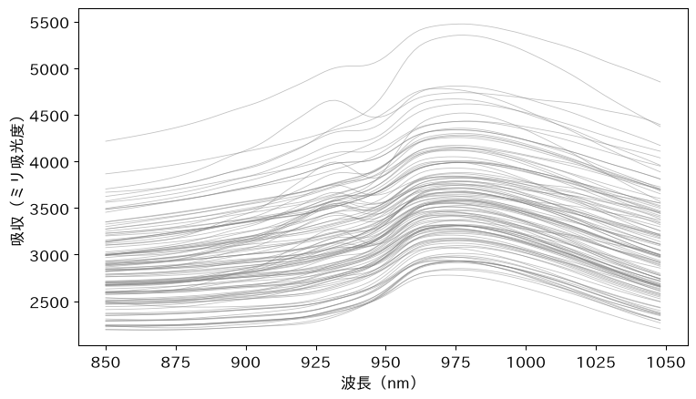

120個の曲線は、形はよく似ていますが、全体の高さが大きく上下しています。

### ここまでで分かったこと

| 段 | 分かったこと |
| --- | --- |
| 作って測る（1・2節） | 100本の普通の式でMAE 3.0%。係数は隣どうしで暴れて読めない |
| 縮める（3節） | ？（このあとの段で） |
| 強さを選ぶ（4節） | ？（このあとの段で） |
| 選ばせる（5節） | ？（このあとの段で） |
| 束で選ぶ（6節） | ？（このあとの段で） |
| 探し方（7節） | ？（このあとの段で） |

まだ分からないのは、係数を落ち着かせて、読める式にできるか、です。

## 3. 係数にペナルティをかける

ここから、段2「縮める」（3節）です。問いは、係数を落ち着かせて、読める式にできるか、です。

隣の3本なら、係数は落ち着いていました。でも、どの3本がよいかは、前もって分かりません。100本のまま、係数だけを落ち着かせられないでしょうか。

### ペナルティを足す

普通の線形回帰は、外れの二乗の和が最小になるように係数を決めました（第2回）。似た列が多いと、大きな+と大きな−を組み合わせて、訓練の肉に合わせ込んでしまいます。

そこで、係数の二乗の和に$\alpha$を掛けて足し、その合計が最小になるように係数を決めます。

$$\sum_{i=1}^{n} (y_i - \hat{y}_i)^2 + \alpha \sum_{j=1}^{100} b_j^2$$

係数が大きいほど、ペナルティが重くなります。外れを小さくしたいが、係数も大きくしたくない。その折り合いで係数を決めます。

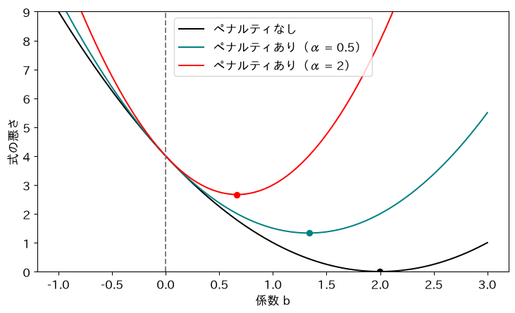

係数が1つの式で見ると、ペナルティなしでは谷底（いちばん外れが小さい係数）は$b = 2$です。ペナルティを足すと、$\alpha$を大きくするほど、谷底が0に近づきます。係数が縮みます。

係数にペナルティをかけて縮めることを、正則化（regularization）と呼びます。二乗の和のペナルティをかけた線形回帰を、リッジ回帰（ridge）と呼びます。$\alpha$はペナルティの強さで、0なら普通の線形回帰、大きいほど係数は0に近づきます。

似た2本に+20と−20をつけても、0.1と0.1をつけても、予測はほとんど同じです。ペナルティがあると、大きな+と−の組み合わせは損になります。似た列どうしで、手柄を小さく分け合う係数が選ばれます。

### お手本：リッジで交差検証

- 役割：ペナルティの強さ1のリッジを、交差検証で測り、普通の式と並べる
- 入力：表`df`、波長の列`waves`
- 出力：5回分のMAEと平均（リッジと普通の式）

`Ridge(alpha=1)`が、ペナルティの強さ1のリッジです。`cv_mae`に渡すだけで、同じ5つの組で測れます。

**書き方メモ（読み飛ばしてよい）**

scikit-learnの`Ridge`は、上の式と同じく、外れの二乗の和に$\alpha \sum_j b_j^2$を足したものを最小にします。切片$b_0$にはペナルティをかけません。

`help(Ridge)`を実行すると、説明書き（ドキュメント）が出ます。Parametersの節に、`alpha`の意味が書いてあります。

```python
cv_r = cv_mae(df, waves, Ridge(alpha=1))
print(np.round(cv_r, 2), round(np.mean(cv_r), 2))
print(np.round(cv_ols, 2), round(np.mean(cv_ols), 2))
```

```
[1.62 1.93 2.14 2.15 2.05] 1.98
[2.55 4.35 2.92 2.99 2.18] 3.0
```

リッジは平均1.98%、普通の式は3.0%です。組ごとに比べても、5つの組すべてでリッジの外れが小さくなりました。ペナルティをかけると、訓練への合わせすぎが抑えられます。

### お手本：係数を描き比べる

- 役割：120個すべてでリッジの式を作り、普通の式の係数と重ねて描く
- 入力：表`df`、2節の普通の式`m_ols`
- 出力：係数の範囲と、2本の折れ線

```
-3.12 2.77
```

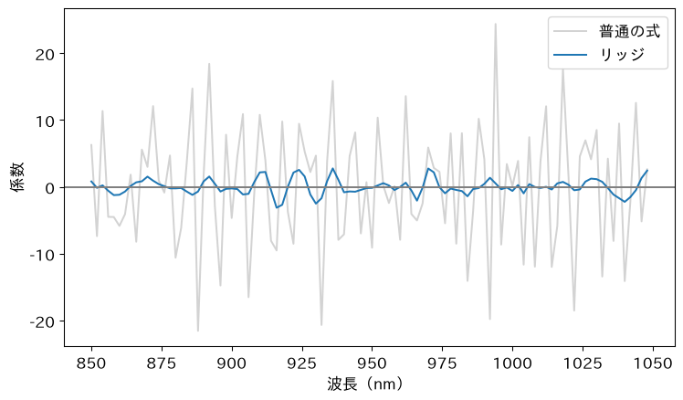

```python
m_r = Ridge(alpha=1).fit(df[waves], df['脂肪'])
print(round(m_r.coef_.min(), 2), round(m_r.coef_.max(), 2))
plt.plot(nm, m_ols.coef_, color='lightgray', label='普通の式')
plt.plot(nm, m_r.coef_, label='リッジ')
plt.axhline(0, color='gray')
plt.xlabel('波長（nm）')
plt.ylabel('係数')
plt.legend()
plt.show()
```

リッジの係数は−3.12〜2.77に縮み、なめらかになりました。

### お手本：組を替えると、リッジの930nmの係数は？

- 役割：2節の`coef_at`にリッジを渡し、5つの組で930nmの係数をためる
- 入力：`Ridge(alpha=1)`
- 出力：5回分の930nmの係数

```python
c930_r = []
for k in range(5):
    c930_r.append(coef_at(Ridge(alpha=1), k, '930'))
print(np.round(c930_r, 2))
```

```
[-2.45 -2.32 -1.39 -2.49 -2.06]
```

930nmの係数は、5回とも−2.49〜−1.39のマイナスで、揺れが小さくなりました。普通の式では、−14.7〜+13.9と符号まで変わっていました。

> 重要：正則化

> 列が多くて係数が暴れるときは、ペナルティをかけて縮める（正則化）。

### TODO②：肉の数を替える（予想 → 実行 → 比べる）

下のセルは、240個から120個を抜き出し、普通の式とリッジを交差検証で測ります。このままだと、上と同じ120個なので、同じ数が出ます。

まず、予想を書いてください。肉を240個（全部）に増やすと、普通の式とリッジの差はどうなるでしょうか。

（ここに予想を書く）

予想を書いたら、セルの`120`を`240`に替えて実行してください。

```python
# TODO: 120 を 240 に替えて実行する
df_n = raw.sample(120, random_state=0).reset_index(drop=True)
df_n['組'] = df_n.index % 5
print(round(np.mean(cv_mae(df_n, waves, LinearRegression())), 2))
print(round(np.mean(cv_mae(df_n, waves, Ridge(alpha=1))), 2))
```

```
3.0
1.98
```

### やってみよう：予想と比べる

実行した結果を、予想と比べてください。肉が増えると、普通の式とリッジの差はどう変わりましたか。下に書いてください。

（ここに答えを書く）

120個では、普通の式3.0%、リッジ1.98%でした。240個にすると、普通の式1.82%、リッジ1.77%で、差はほとんど消えます。

肉が少なく列が多いと、普通の式は訓練の肉に合わせすぎ、ペナルティがよく効きます。肉が増えれば、普通の式でも係数が決まりやすくなり、ペナルティの出番は減ります。

> 重要：効き目はデータしだい

> データが少なく列が多いほど、ペナルティが効く。データが増えれば、普通の式でも係数が決まりやすくなる。

### ここまでで分かったこと

| 段 | 分かったこと |
| --- | --- |
| 作って測る（1・2節） | 100本の普通の式でMAE 3.0%。係数は隣どうしで暴れて読めない |
| 縮める（3節） | リッジでペナルティをかけると1.98%。係数も落ち着く |
| 強さを選ぶ（4節） | ？（このあとの段で） |
| 選ばせる（5節） | ？（このあとの段で） |
| 束で選ぶ（6節） | ？（このあとの段で） |
| 探し方（7節） | ？（このあとの段で） |

まだ分からないのは、$\alpha$を1にしたのはなぜか、です。

## 4. αはいくつ？

ここから、段3「強さを選ぶ」（4節）です。問いは、ペナルティの強さ$\alpha$をいくつにすればよいか、です。

3節では、$\alpha = 1$と決め打ちしました。ペナルティが弱すぎれば、普通の式と同じです。強すぎれば、係数がみな0に近づき、何も当てられません。ちょうどよい強さは、どう決めればよいでしょうか。

### ハイパーパラメータとチューニング

係数$b_j$は、`fit`がデータから決めます。$\alpha$は、`fit`の前に、人が決めて渡します。このように人が決める設定を、ハイパーパラメータ（hyperparameter）と呼びます。

$\alpha$の候補を並べ、それぞれで交差検証のMAEを測り、いちばんMAEの小さい$\alpha$を選びます。これをチューニング（tuning）と呼びます。第4回の交差検証が、そのまま選ぶ道具になります。

### 新しい書き方：辞書

第4回は、くり返しの結果をリストにためました。リストは、0番目・1番目…と順番で引きます。今日は「$\alpha = 10$のときのMAE」と、$\alpha$の値で引きたいのです。

名札（キー）と中身（値）の組をためる入れ物が、辞書です。`{}`で空の辞書を作り、`d[キー] = 値`でしまい、`d[キー]`で取り出します。

```python
d = {}             # 空の辞書
d['りんご'] = 120   # 名札'りんご'に120をしまう
d['みかん'] = 80    # 名札'みかん'に80をしまう
print(d['みかん'])  # 80
```

**書き方メモ（読み飛ばしてよい）**

同じ名札にもう一度しまうと、中身が置き換わります。名札は1つの辞書に1つずつです。

`for キー in 辞書:`は、辞書の名札を、しまった順に1つずつ取り出します。

`d.keys()`は名札の並び、`d.values()`は中身の並びです。図に渡すときは、`list(...)`でリストに直します。

### お手本：αごとのMAEを辞書にためる

- 役割：$\alpha$を6通りに変えてリッジを交差検証で測り、MAEの平均を、$\alpha$を名札にして辞書`maes`にためる
- 入力：表`df`、波長の列`waves`
- 出力：$\alpha$とMAEの組

`for a in maes:`で、辞書の名札を1つずつ取り出して表示します。

```python
maes = {}
for a in [0.01, 0.1, 1, 10, 100, 1000]:
    maes[a] = np.mean(cv_mae(df, waves, Ridge(alpha=a)))
for a in maes:
    print(a, round(maes[a], 2))
```

```
0.01 2.33
0.1 2.02
1 1.98
10 2.33
100 2.51
1000 2.52
```

`for`が1回まわるたびに、名札$\alpha$の引き出しが1つ増え、そこにMAEがしまわれます。`maes[1]`で、$\alpha = 1$の引き出しを開けます。

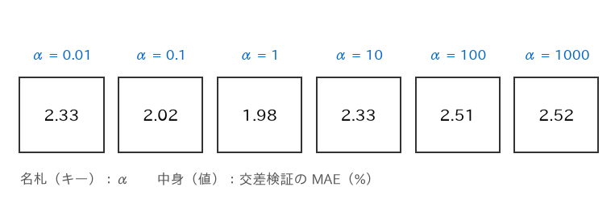

#### 1行ずつ読む

- 1行目：空の辞書を作り、`maes`と名付ける
- 2行目：`a`に0.01、0.1、…、1000を順に入れ、字下げした3行目をくり返す
- 3行目：右側で、そのαのリッジを交差検証で測り、5つの組のMAEを平均する。その平均を、名札`a`の引き出しにしまう（`maes[a] = 値`）。名札は0番目・1番目ではなく、αの値そのもの
- 4行目：`for a in maes:`で、辞書の名札を、しまった順に1つずつ取り出す
- 5行目：`maes[a]`で、名札`a`の引き出しを開け、小数2桁に丸めて出す

#### 中身を見る：2回まわした辞書

```python
maes2 = {}
for a in [0.01, 0.1]:
    maes2[a] = np.mean(cv_mae(df, waves, Ridge(alpha=a)))
    print(list(maes2.keys()), round(maes2[a], 2))
```

```
[0.01] 2.33
[0.01, 0.1] 2.02
```

`list(maes2.keys())`は、名札の並びです。1回まわるたびに、名札が1つ増えます。名札0.01の中身は2.33、名札0.1の中身は2.02です。

### お手本：αとMAEを描く

- 役割：辞書の名札（$\alpha$）を横軸、中身（MAE）を縦軸にして描く
- 入力：辞書`maes`
- 出力：折れ線

`list(maes.keys())`は名札のリスト、`list(maes.values())`は中身のリストです。`plt.xscale('log')`で、横軸を10倍ごとに等しい幅にします。

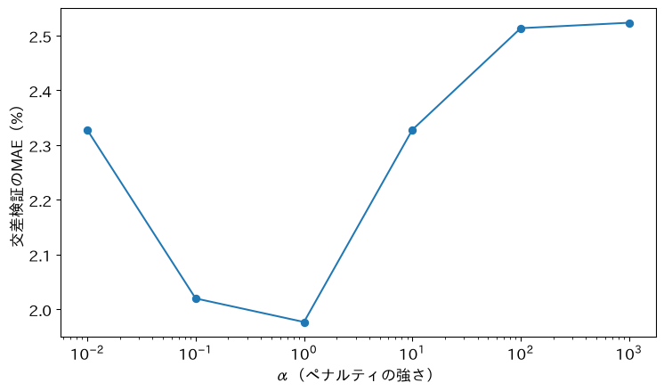

```python
plt.plot(list(maes.keys()), list(maes.values()), 'o-')
plt.xscale('log')
plt.xlabel('α（ペナルティの強さ）')
plt.ylabel('交差検証のMAE（%）')
plt.show()
```

$\alpha = 1$の1.98%がいちばん小さく、両側で外れが増えます。弱すぎても、強すぎても悪いのです。

### お手本：いちばん小さいα

- 役割：辞書`maes`の中から、MAEがいちばん小さい名札を選ぶ
- 入力：辞書`maes`
- 出力：選んだ$\alpha$と、そのMAE

**書き方メモ（読み飛ばしてよい）**

`min(maes, key=maes.get)`は、名札の中から、`maes.get(名札)`（＝中身）がいちばん小さい名札を返します。`key=`は「何で比べるか」の指定です。

```python
best_a = min(maes, key=maes.get)
print(best_a, round(maes[best_a], 2))
```

```
1 1.98
```

### 解パス：αを動かすと、係数はどう動くか

$\alpha$を動かしたときの係数の動きを描いた図を、解パス（solution path）と呼びます。$\alpha$ごとに120個すべてでリッジを作り、係数を辞書にためて描きます。灰色が100本の係数、赤が930nmの係数、青い点線が選んだ$\alpha = 1$です。

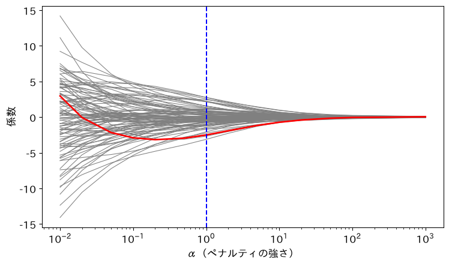

左（ペナルティが弱い）では、係数が大きく+と−に暴れています。右（強い）では、どの係数もそろって0へ縮みます。交差検証で選んだ$\alpha = 1$では、係数はまだ0ではありません。暴れは収まり、形は残っています。交差検証は、暴れすぎと縮めすぎの間を選んでいます。

> 重要：αは交差検証で選ぶ

> 係数はデータが決める。ハイパーパラメータ（α）は、人が候補を並べ、交差検証で比べて選ぶ。

### TODO③：αの候補を足す（予想 → 実行 → 比べる）

下のセルは、$\alpha = 0.3$のMAEを測り、辞書`maes`に足します。

まず、予想を書いてください。$\alpha = 0.3$は、いま選んだ$\alpha = 1$より良いでしょうか、悪いでしょうか。

（ここに予想を書く）

予想を書いて実行したら、`0.3`を別の数（たとえば`3`や`0.03`）にも替えて実行してみてください。

```python
# TODO: 0.3 を別の数（たとえば 3 や 0.03）に替えて実行する
a = 0.3
maes[a] = np.mean(cv_mae(df, waves, Ridge(alpha=a)))
print(a, round(maes[a], 2))
```

```
0.3 1.95
```

### やってみよう：予想と比べる

実行した結果を、予想と比べてください。$\alpha$の候補の並べ方について、気づいたことを書いてください。

（ここに答えを書く）

$\alpha = 0.3$は1.95%で、$\alpha = 1$の1.98%より少し良くなりました。候補にない$\alpha$は選べません。まず10倍ごとに粗く並べ、良さそうなあたりを細かく足します。

ただ、1.95%と1.98%の差は、組の分け方で揺れる程度の小さな差です。細かく詰めすぎても、意味のある違いにはなりません。

### ここまでで分かったこと

| 段 | 分かったこと |
| --- | --- |
| 作って測る（1・2節） | 100本の普通の式でMAE 3.0%。係数は隣どうしで暴れて読めない |
| 縮める（3節） | リッジでペナルティをかけると1.98%。係数も落ち着く |
| 強さを選ぶ（4節） | αを辞書にためて交差検証で比べ、α = 1を選ぶ |
| 選ばせる（5節） | ？（このあとの段で） |
| 束で選ぶ（6節） | ？（このあとの段で） |
| 探し方（7節） | ？（このあとの段で） |

まだ分からないのは、100本のうち、どの波長が脂肪を教えているか、です。

## 5. 効く波長だけ残せる？

ここから、段4「選ばせる」（5節）です。問いは、100本のうち、効く波長だけを残せるか、です。

ペナルティの強さは、交差検証で選べました。でもリッジは、どの係数も小さくするだけで、ちょうど0にはしません。説明に使うなら、効く波長だけが残ってほしいところです。

### ペナルティを、絶対値の和に替える：ラッソ

二乗の和の代わりに、係数の絶対値の和にペナルティをかけます。

$$\sum_{i=1}^{n} (y_i - \hat{y}_i)^2 + \alpha \sum_{j=1}^{100} \lvert b_j \rvert$$

この線形回帰を、ラッソ（lasso）と呼びます。

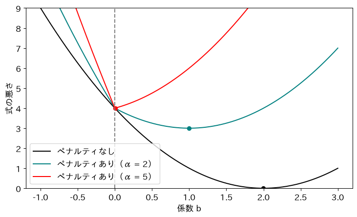

絶対値のペナルティは、$b = 0$で折れ曲がります。ペナルティを強くすると、谷底がちょうど0に止まります。係数が0の波長は、予測に使われず、式から消えます。$\alpha$を大きくするほど、0になる波長が増え、残る波長が減ります。ラッソは、係数を縮めながら、波長を選びます。

### お手本：ラッソで残る波長

- 役割：ペナルティの強さ100のラッソを120個すべてで作り、係数が0でない波長を表示する。交差検証でも測る
- 入力：表`df`、波長の列`waves`
- 出力：残った波長の名前と、交差検証のMAE

`coef_l[coef_l != 0]`は、係数が0でない波長だけに絞った並びで、`.index`でその名前を取り出します（第1回の、条件で絞る書き方です）。

**書き方メモ（読み飛ばしてよい）**

`max_iter`は、係数を少しずつ直していく計算を、くり返す上限の回数です。似た列が多いと、なかなか収まらず、多めに要ります。足りないと「ConvergenceWarning（収まらなかった）」という警告が出ます。そのときは`max_iter`を増やします。

scikit-learnの`Lasso`の式は、外れの二乗の和を$2n$で割ってからペナルティを足す形です（$n$は行の数）。そのため、同じ$\alpha$でも、リッジとラッソでペナルティの効き方の目盛りが違います。$\alpha$は、ラッソはラッソで、交差検証で選び直します。

```python
m_l = Lasso(alpha=100, max_iter=100000)
m_l.fit(df[waves], df['脂肪'])
coef_l = pd.Series(m_l.coef_, index=waves)
print(list(coef_l[coef_l != 0].index))
print(round(np.mean(cv_mae(df, waves, m_l)), 2))
```

```
['870', '872', '874', '930', '956']
3.89
```

残ったのは870・872・874・930・956nmの5本です。外れは3.89%で、リッジの1.98%より悪くなりますが、5本だけで当てています。これで「効く波長」が分かったのでしょうか。

### ラッソの解パス

同じ解パスを、ラッソでも描きます。右（ペナルティが強い）から左へ、$\alpha$を弱めていく向きに読みます。青い点線は、いま使った$\alpha = 100$です。

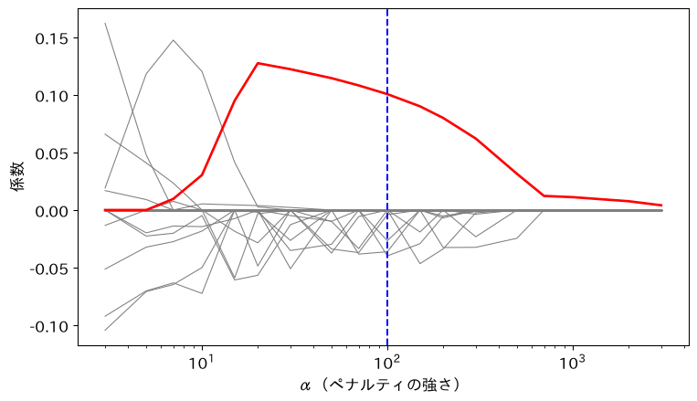

```
['930']
```

強いところでは、ほとんどの係数がちょうど0です。$\alpha$を弱めるにつれ、係数が1本ずつ0から離れ、波長が式に入ってきます。いちばん強い$\alpha = 3000$まで残るのは、930nmの1本です（図の下の表示）。

ほかの灰色の線は、短く出ては消えます。$\alpha$を少し変えるだけで、選ばれる波長が隣の波長と入れ替わっています。$\alpha$を少し変えただけで入れ替わるなら、肉を少し変えたら、どうなるでしょうか。

### お手本：肉を取り直して、選び直す

本当に効く波長なら、肉が少し違っても、同じ波長が選ばれるはずです。120個から96個をくじで取り直し、ラッソで選び直します。

- 役割：番号`s`のくじで96個を取り直して式を作り、係数が0でない波長の名前のリストを返す
- 入力：式の作り方`model`、くじの番号`s`
- 出力：選ばれた波長の名前のリスト

```python
def picked(model, s):
    sub = df.sample(96, random_state=s)
    model.fit(sub[waves], sub['脂肪'])
    coef = pd.Series(model.coef_, index=waves)
    return list(coef[coef != 0].index)

for s in range(3):
    print(picked(Lasso(alpha=100, max_iter=100000), s))
```

```
['868', '870', '872', '930', '956', '958']
['868', '870', '872', '930', '956']
['870', '872', '930', '956']
```

### お手本：波長ごとに、選ばれた回数を数える

- 役割：100本の波長を名札にして0を入れた辞書を用意し、20回取り直して、選ばれた波長の数を1つずつ増やす
- 入力：`picked`、ラッソ
- 出力：868〜874nmの選ばれた回数

外の`for`は取り直しの20回、中の`for`は、その回に選ばれた波長の1本ずつです。選ばれるたびに、その波長の引き出しの数を1つ増やします。

```python
counts = {}
for w in waves:
    counts[w] = 0                    # 100本の名札を0で用意
for s in range(20):
    for w in picked(Lasso(alpha=100, max_iter=100000), s):
        counts[w] = counts[w] + 1    # 選ばれた波長に1を足す
print(counts['868'], counts['870'], counts['872'], counts['874'])
```

```
7 20 18 12
```

#### 1行ずつ読む

- 1行目：空の辞書を作り、`counts`と名付ける
- 2・3行目：100本の波長`w`を1本ずつ名札にして、中身を0にする。先に0を入れておくのは、4〜6行目で「今の数に1を足す」ため
- 4行目：くじの番号`s`を0から19まで変え、取り直しを20回くり返す
- 5行目：その回に選ばれた波長のリストから、1本ずつ`w`に取り出す。外の`for`は回、中の`for`はその回に選ばれた波長
- 6行目：右側で名札`w`の今の数を取り出して1を足し、同じ名札にしまい直す
- 7行目：4本の波長の名札を開けて、選ばれた回数を出す

#### 中身を見る：3回まわした数

```python
counts3 = {}
for w in waves:
    counts3[w] = 0
for s in range(3):
    for w in picked(Lasso(alpha=100, max_iter=100000), s):
        counts3[w] = counts3[w] + 1
    print(s, counts3['868'], counts3['874'])
```

```
0 1 0
1 2 0
2 2 0
```

左から、くじの番号`s`（0が1回目）、868nmの数、874nmの数です。868nmは、1・2回目に選ばれて1、2と増え、3回目は選ばれず2のままです。874nmは、3回とも選ばれず0のままです。

### お手本：回数を棒で描く

- 役割：波長ごとの選ばれた回数を、棒で描く
- 入力：辞書`counts`、波長の数`nm`
- 出力：棒グラフ

`list(counts.values())`は、辞書の中身（回数）を、名札をしまった順（波長の順）に並べたリストです。`width=1.6`は棒の幅です。

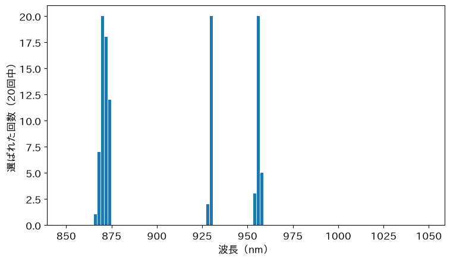

```python
plt.bar(nm, list(counts.values()), width=1.6)
plt.xlabel('波長（nm）')
plt.ylabel('選ばれた回数（20回中）')
plt.show()
```

20回とも選ばれたのは、870・930・956nmだけです。872nmは18回、874nmは12回、868nmは7回と、隣どうしで入れ替わります。

870〜874nmは、ほとんど同じことを言う群れです。ラッソは、群れの中から、たまたま1〜2本を選びます。選ばれなかった隣の波長も、同じくらい効いているはずです。

> 重要：ラッソは群れから1本

> ラッソは、似た列の群れから1本をたまたま選ぶ。選ばれなかった列が効かないとは限らない。

> 今日の重要概念（Python）：辞書

> 名札（キー）と中身（値）の組をためる入れ物が辞書。`d[キー] = 値`でしまい、`d[キー]`で名前から引く。

### TODO④：ラッソのαを替える（予想 → 実行 → 比べる）

下のセルは、上と同じく、ラッソで20回取り直して選ばれた回数を数え、棒で描きます。

まず、予想を書いてください。ペナルティを弱く（$\alpha$を100から30に）すると、選ばれる波長の数と、その揺れはどうなるでしょうか。

（ここに予想を書く）

予想を書いたら、セルの`alpha=100`の`100`を`30`に替えて実行してください。

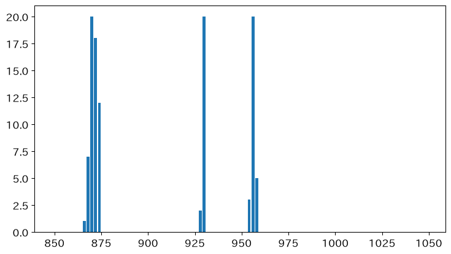

```python
# TODO: 100 を 30 に替えて実行する
counts_x = {}
for w in waves:
    counts_x[w] = 0
for s in range(20):
    for w in picked(Lasso(alpha=100, max_iter=100000), s):
        counts_x[w] = counts_x[w] + 1
plt.bar(nm, list(counts_x.values()), width=1.6)
plt.show()
```

### やってみよう：予想と比べる

実行した結果を、予想と比べてください。20回とも選ばれた波長は、いくつありますか。隣どうしの入れ替わりは、なくなりましたか。下に書いてください。

（ここに答えを書く）

ペナルティを弱くすると、選ばれる波長は増えます。でも、棒が20回に届くのは2本だけです。ほかの棒は、隣どうしで高さを分け合っていて、やはり取り直すたびに入れ替わっています。

揺れは、ペナルティの強さではなく、似た列の群れから生まれています。

### ここまでで分かったこと

| 段 | 分かったこと |
| --- | --- |
| 作って測る（1・2節） | 100本の普通の式でMAE 3.0%。係数は隣どうしで暴れて読めない |
| 縮める（3節） | リッジでペナルティをかけると1.98%。係数も落ち着く |
| 強さを選ぶ（4節） | αを辞書にためて交差検証で比べ、α = 1を選ぶ |
| 選ばせる（5節） | ラッソは数本に絞るが、取り直すたびに隣の波長と入れ替わる |
| 束で選ぶ（6節） | ？（このあとの段で） |
| 探し方（7節） | ？（このあとの段で） |

まだ分からないのは、揺れずに、効く波長を選べるか、です。

## 6. 揺れずに選ぶには？

ここから、段5「束で選ぶ」（6節）です。問いは、似た波長の群れを、揺れずに選べるか、です。

リッジは、似た列で手柄を分け合いましたが、0にはしませんでした。ラッソは、0にして選びましたが、群れから1本だけでした。2つのペナルティを混ぜたら、群れごと選べないでしょうか。

### 2つのペナルティを混ぜる：エラスティックネット

絶対値のペナルティ（ラッソ）を割合$r$、二乗のペナルティ（リッジ）を残りで混ぜたペナルティをかけます。

$$\alpha \left( r \sum_{j} \lvert b_j \rvert + \frac{1 - r}{2} \sum_{j} b_j^2 \right)$$

この線形回帰を、エラスティックネット（elastic net）と呼びます。$r = 1$ならラッソ、$r$を0に近づけるほどリッジに近くなります。絶対値のペナルティで0にして選び、二乗のペナルティで似た列に手柄を分け合わせます。scikit-learnでは、$r$を`l1_ratio`と呼びます。

### お手本：エラスティックネットで、選ばれた回数を数える

- 役割：5節と同じ手順で、エラスティックネット（$\alpha = 100$、$r = 0.1$）が20回で選んだ回数を数え、棒で描く
- 入力：`picked`、エラスティックネット
- 出力：棒グラフ

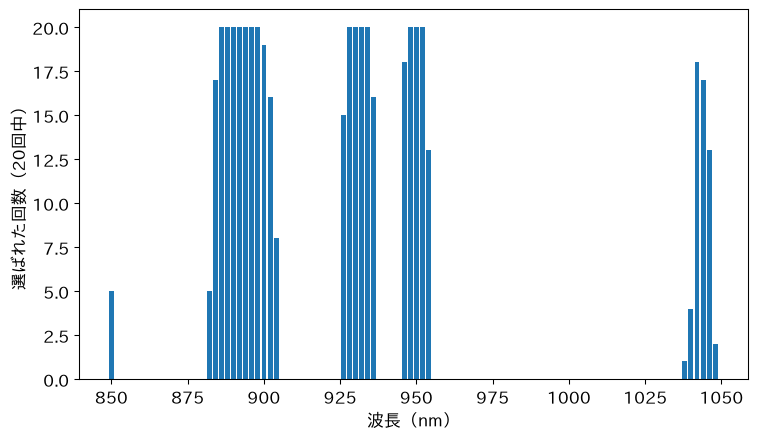

```python
counts_e = {}
for w in waves:
    counts_e[w] = 0
for s in range(20):
    m = ElasticNet(alpha=100, l1_ratio=0.1, max_iter=100000)
    for w in picked(m, s):
        counts_e[w] = counts_e[w] + 1
plt.bar(nm, list(counts_e.values()), width=1.6)
plt.xlabel('波長（nm）')
plt.ylabel('選ばれた回数（20回中）')
plt.show()
```

### お手本：20回とも選ばれた波長

- 役割：20回とも選ばれた波長の名前を、リストに集める
- 入力：辞書`counts_e`
- 出力：波長の名前のリスト

```python
always = []
for w in counts_e:
    if counts_e[w] == 20:
        always.append(w)
print(always)
```

```
['886', '888', '890', '892', '894', '896', '898', '928', '930', '932', '934', '948', '950', '952']
```

20回とも選ばれた波長が、886〜898nm、928〜934nm、948〜952nmと、隣どうしでつながって帯になりました。ラッソでは、群れから1本が入れ替わりで選ばれました。エラスティックネットは、群れの全員に手柄を分け合わせるので、選んだ帯が揺れにくいのです。

### お手本：外れは？

- 役割：エラスティックネットを交差検証で測る
- 入力：表`df`、波長の列`waves`
- 出力：交差検証のMAE

```python
m_e = ElasticNet(alpha=100, l1_ratio=0.1, max_iter=100000)
print(round(np.mean(cv_mae(df, waves, m_e)), 2))
```

```
3.11
```

3.11%です。ラッソ（3.89%）より良く、リッジ（1.98%）よりは悪い外れです。

### TODO⑤：混ぜる割合を替える（予想 → 実行 → 比べる）

下のセルは、上と同じく、エラスティックネットで20回取り直して選ばれた回数を数え、棒で描きます。

まず、予想を書いてください。混ぜる割合$r$を0.1から0.5に替えて、ラッソ寄りにすると、帯はどうなるでしょうか。

（ここに予想を書く）

予想を書いたら、セルの`r_x = 0.1`の`0.1`を`0.5`に替えて実行してください。

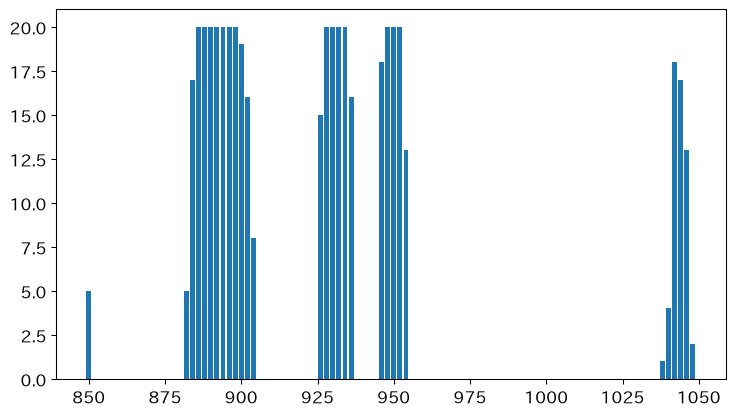

```python
# TODO: 0.1 を 0.5 に替えて実行する
r_x = 0.1
counts_x = {}
for w in waves:
    counts_x[w] = 0
for s in range(20):
    m = ElasticNet(alpha=100, l1_ratio=r_x, max_iter=100000)
    for w in picked(m, s):
        counts_x[w] = counts_x[w] + 1
plt.bar(nm, list(counts_x.values()), width=1.6)
plt.show()
```

### やってみよう：予想と比べる

実行した結果を、予想と比べてください。帯の幅は、どう変わりましたか。下に書いてください。

（ここに答えを書く）

$r = 0.5$にすると、20回とも選ばれた波長は7本になり、$r = 0.1$の14本から半分に減ります。$r$を1に近づけるほどラッソに近づき、群れから少しだけ選びます。$r$を0に近づけるほどリッジに近づき、群れごと残します。$\alpha$と$r$の選び方しだいで、選ばれる波長が変わります。

### ここまでで分かったこと

| 段 | 分かったこと |
| --- | --- |
| 作って測る（1・2節） | 100本の普通の式でMAE 3.0%。係数は隣どうしで暴れて読めない |
| 縮める（3節） | リッジでペナルティをかけると1.98%。係数も落ち着く |
| 強さを選ぶ（4節） | αを辞書にためて交差検証で比べ、α = 1を選ぶ |
| 選ばせる（5節） | ラッソは数本に絞るが、取り直すたびに隣の波長と入れ替わる |
| 束で選ぶ（6節） | エラスティックネットは帯で残し、取り直しても揺れない |
| 探し方（7節） | ？（このあとの段で） |

まだ分からないのは、$\alpha$と$r$を、どう選ぶか、です。

## 7. つまみ2つを、どう探す？

ここから、最後の段、段6「探し方」（7節）です。問いは、$\alpha$と$r$、2つのつまみをどう探すか、です。

6節では、$\alpha = 100$・$r = 0.1$と決め打ちしました。4節では、つまみは$\alpha$の1つで、候補を辞書にため、交差検証で比べました。エラスティックネットには、$\alpha$と$r$の2つのハイパーパラメータがあります。探し方は2つあります。全部の組を試すか、1つずつ動かすかです。

### 探し方①：グリッドサーチ

$\alpha$の候補と$r$の候補を、格子（grid）に並べ、格子のすべての組で交差検証のMAEを測ります。全部を探すので、グリッドサーチ（grid search）と呼びます。

### 道具：格子の表を作る関数（中身は読み飛ばしてよい）

- 役割：$\alpha$と$r$の候補のすべての組み合わせで、交差検証のMAE（`grid_mae`）と、120個すべてで作ったときに残る波長の数（`grid_count`）を表にする
- 入力：$\alpha$の候補`alphas`、$r$の候補`ratios`
- 出力：行が$r$、列が$\alpha$の表

### お手本：グリッドサーチ

- 役割：$\alpha$を30・100・300・1000、$r$を0.2・0.5・1.0に並べ、12通りのMAEと残る波長の数を表にする
- 入力：候補`alphas`と`ratios`
- 出力：2つの表（行が$r$、列が$\alpha$）と、交差検証をした回数

計算に、10〜20秒ほどかかります。

**書き方メモ（読み飛ばしてよい）**

$\alpha$も$r$も小さい組（たとえば$\alpha = 10$・$r = 0.1$）は、似た列が多いこのデータでは、係数を直していく計算がなかなか収まらず、1つの組に数秒かかります。しかも`max_iter`の上限まで回っても収まりきらず、結果も確かではありません。そこで、候補は、計算が収まる範囲から選びました。候補を決めるときは、外れだけでなく、計算にかかる時間も考えます。

```python
alphas = [30, 100, 300, 1000]
ratios = [0.2, 0.5, 1.0]
print(grid_mae(alphas, ratios))      # 交差検証のMAE
print(grid_count(alphas, ratios))    # 残る波長の数
print(len(alphas) * len(ratios))     # 交差検証をした回数
```

```
     30    100   300    1000
0.2  2.92  3.26  3.65   5.11
0.5  3.16  3.53  4.47   8.76
1.0  3.36  3.89  6.17  10.26
     30    100   300   1000
0.2    21    18    17    22
0.5    10    12    15     7
1.0     7     5     6     1
12
```

MAEは、$\alpha$も$r$も小さいほど良くなります。残る波長は、$r$が大きいほど少なくなります。12通りでいちばん小さいのは、$\alpha = 30$・$r = 0.2$の2.92%で、残る波長は21本です。

全部試すと、回数は掛け算で増えます。候補が4通りと3通りで$4 \times 3 = 12$回です。つまみが3つで10通りずつなら、$10 \times 10 \times 10$回です。しかも1回の交差検証で、式を5回作ります。

### 探し方②：貪欲法

つまみを1つずつ動かし、ほかのつまみは止めておきます。まず$\alpha$を止めて$r$を選び、次にその$r$に止めて$\alpha$を選びます。その場その場でいちばん良いものを取るので、貪欲法（greedy）と呼びます。

### お手本：1つずつ動かす関数

- 役割：`tune_r`は$\alpha$を止めて、$r$の候補ごとのMAEを辞書で返す。`tune_a`はその逆で、$r$を止めて$\alpha$を動かす
- 入力：止めておく$\alpha$（または$r$）
- 出力：名札が$r$（または$\alpha$）、中身がMAEの辞書

```python
def tune_r(a):
    maes_r = {}
    for r in ratios:
        model = ElasticNet(alpha=a, l1_ratio=r, max_iter=100000)
        maes_r[r] = np.mean(cv_mae(df, waves, model))
    return maes_r


def tune_a(r):
    maes_a = {}
    for a in alphas:
        model = ElasticNet(alpha=a, l1_ratio=r, max_iter=100000)
        maes_a[a] = np.mean(cv_mae(df, waves, model))
    return maes_a
```

### お手本：貪欲法で探す

- 役割：$\alpha = 100$（5節のラッソ）から出発し、$r$、$\alpha$の順に1つずつ選ぶ
- 入力：`tune_r`・`tune_a`
- 出力：着いた$\alpha$と$r$、そのMAE、交差検証をした回数

`len(辞書)`は、辞書にしまった組の数です。2つの辞書の数を足すと、交差検証をした回数になります。

```python
maes_r = tune_r(100)                   # αを100に止めて、rを動かす
best_r = min(maes_r, key=maes_r.get)
maes_a = tune_a(best_r)                # rを止めて、αを動かす
best_a2 = min(maes_a, key=maes_a.get)
print(best_a2, best_r, round(maes_a[best_a2], 2))
print(len(maes_r) + len(maes_a))       # 交差検証をした回数
```

```
30 0.2 2.92
7
```

まず$\alpha = 100$の列を縦に動いて$r = 0.2$を選び、次に$r = 0.2$の行を横に動いて$\alpha = 30$を選びました。着いたのは$\alpha = 30$・$r = 0.2$で、外れは2.92%です。

グリッドサーチは12回、貪欲法は7回で、同じ組に着きました。このデータでは、外れの谷が素直な形なので、1つずつ動かしても谷底に着きます。

### 貪欲法が見逃すとき

```
      A1   A2   A3    A4    A5
B1   5.4  4.8  6.4  10.4  16.6
B2   4.8  2.4  2.3   4.6   9.2
B3   6.4  2.3  0.6   1.2   4.0
B4  10.4  4.6  1.2   0.0   1.2
B5  16.6  9.2  4.0   1.2   0.6
```

> 今日の重要概念（統計）：ハイパーパラメータ

> ハイパーパラメータは、候補を並べ、交差検証で比べて選ぶ（チューニング）。全部の組を試すグリッドサーチは確実だが回数が掛け算で増え、1つずつ動かす貪欲法は速いが、いちばん良い組を見逃すことがある。

### 何のために選ぶか

当てるだけなら、リッジ（1.98%）がいちばん良い式です。波長を選んで説明したいなら、エラスティックネットを使います。選んだ組（$\alpha = 30$・$r = 0.2$）は21本で2.92%で、6節の組（$\alpha = 100$・$r = 0.1$）の3.11%より、外れが小さくなりました。

> 重要：目的で選ぶ

> 波長を選ぶと、当たりは少し落ちる。当てるためか、説明するためかで、ペナルティの種類を選ぶ。

### 残った帯は、どこ？

エラスティックネットが20回とも残した帯を、脂肪の少ない肉と多い肉のスペクトルに重ねます。

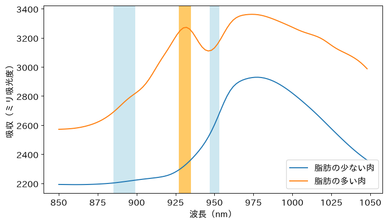

橙の帯は、930nmのまわりです。930nmのまわりは、脂肪の分子（炭素と水素の結びつき）が光を吸う波長として知られています。脂肪の多い肉は、930nmのあたりに小さな山があります。

化学の知識を何も教えていないのに、式は930nmのまわりを選びました。今日の一周で見た「えっ」の答えです。正則化で係数を落ち着かせ、群れごと選んだから、読める形になりました。ほかの帯が何を表すかは、まだ言えません。

### TODO⑥：αの候補を1つ足す（予想 → 実行 → 比べる）

下のセルは、グリッドサーチと貪欲法で、交差検証をする回数を表示します。

まず、予想を書いてください。$\alpha$の候補に3000を1つ足すと、グリッドサーチと貪欲法の回数は、それぞれ何回増えるでしょうか。

（ここに予想を書く）

予想を書いたら、`alphas`の最後に`3000`を足して（`[30, 100, 300, 1000, 3000]`にして）実行してください。

```python
# TODO: alphas の最後に 3000 を足して実行する
alphas = [30, 100, 300, 1000]
print(len(alphas) * len(ratios))       # グリッドサーチの回数
maes_r = tune_r(100)
best_r = min(maes_r, key=maes_r.get)
maes_a = tune_a(best_r)
print(len(maes_r) + len(maes_a))       # 貪欲法の回数
```

```
12
7
```

### やってみよう：予想と比べる

実行した結果を、予想と比べてください。回数の増え方は、2つの探し方でどう違いましたか。下に書いてください。

（ここに答えを書く）

グリッドサーチは12回から15回に、3回（$r$の候補の数だけ）増えます。貪欲法は7回から8回に、1回だけ増えます。グリッドサーチの回数は候補の数の掛け算で、貪欲法は足し算です。つまみや候補が増えるほど、差が開きます。回数と確かさの折り合いで、探し方を選びます。

### ここまでで分かったこと

| 段 | 分かったこと |
| --- | --- |
| 作って測る（1・2節） | 100本の普通の式でMAE 3.0%。係数は隣どうしで暴れて読めない |
| 縮める（3節） | リッジでペナルティをかけると1.98%。係数も落ち着く |
| 強さを選ぶ（4節） | αを辞書にためて交差検証で比べ、α = 1を選ぶ |
| 選ばせる（5節） | ラッソは数本に絞るが、取り直すたびに隣の波長と入れ替わる |
| 束で選ぶ（6節） | エラスティックネットは帯で残し、取り直しても揺れない |
| 探し方（7節） | 全部試すと12回、1つずつなら7回で同じ組。帯の1つは930nm |

6つの段がそろい、今日の問いに答えられます。

### 答え

光のスペクトルだけで、脂肪の割合は、交差検証で平均1.98%の外れで当たります（リッジ、$\alpha = 1$）。化学分析をしなくても、光で肉の脂肪を見積もれます。

脂肪を教えているのは、930nmのまわりの帯です（エラスティックネット）。100本の普通の式の係数は、隣どうしで暴れて読めませんでした。ペナルティをかけて縮め、似た波長を束で選ぶと、化学の知識と合う波長が見えてきました。

まだ言えないこと

- ほかの帯：890nmや950nmのまわりの帯が、何を表すか
- 水分やたんぱく質：同じ手順で当てられるか、選ぶ波長は同じか
- 肉が違えば：別の工場や別の装置の肉でも、同じ式が使えるか

## 目標に答えられたか

- 今日の目標は「光の吸収スペクトルから、肉の脂肪はどこまで分かるか」でした。交差検証のMAEと、効く波長で答えられますか？
- 2節で、100本の普通の式の係数が読めなかったのはなぜですか？
- TODO①で、1本では当たらないのに、隣の3本で当たったのはなぜですか？
- 3節で、ペナルティをかけると、係数と外れはそれぞれどうなりましたか？
- 4節で、$\alpha$はどうやって選びましたか？ 辞書は、そこで何の役に立ちましたか？
- 5節で、ラッソの選んだ波長が、取り直すたびに入れ替わったのはなぜですか？
- 6節で、エラスティックネットは何を選びましたか？ リッジとエラスティックネットは、どう使い分けますか？
- 7節で、グリッドサーチと貪欲法は、回数と着いた組がどう違いましたか？

## 今日の要点

- 今日、持ち帰る1文：スペクトルのように列が多く、隣どうしが似ていると、普通の式の係数は暴れる。ペナルティをかけて縮める（正則化）と、当たりが良くなり、係数も読める。ラッソは似た列の群れから1本をたまたま選ぶので、群れを束で残すならエラスティックネット。ペナルティの種類と強さは、交差検証で選ぶ。つまみが2つなら、全部の組を試すか、1つずつ動かすか
- 重要概念（統計）：ハイパーパラメータ。ハイパーパラメータは、候補を並べ、交差検証で比べて選ぶ。全部の組を試すグリッドサーチは確実だが回数が掛け算で増え、1つずつ動かす貪欲法は速いが、いちばん良い組を見逃すことがある
- 重要概念（Python）：辞書。名札（キー）と中身（値）の組をためる。`d[キー] = 値`でしまい、`d[キー]`で名前から引く
- 似た列がたくさんあると、予測はそこそこでも係数は暴れる（多重共線性）
- リッジは縮める、ラッソは0にして選ぶ、エラスティックネットは束で選ぶ。何のために選ぶかで、種類を決める
- ハイパーパラメータは交差検証で選ぶ。全部の組を試すか、1つずつ動かすか

### 正則化の広がり

列が多いデータは、肉のスペクトルだけではありません。遺伝子では、1人から2万ほどの遺伝子の量を測れますが、測れる人は数百人ほどです。画像は1枚に数万の画素があり、文章には数万の種類の単語が出てきます。試料より列のほうが多いデータは、いまでは珍しくありません。

そのため、ペナルティをかける考えは、あちこちで働いています。病気に関わる遺伝子を数万の中から選ぶのにラッソが使われ、MRIの撮影を短くする技術にも、ラッソと同じ絶対値のペナルティが入っています。画像や文章を学ぶAIも、学習のときに係数を縮めるペナルティをかけることが多くあります。

どれも、外れの二乗和にペナルティを足して、いちばん小さくなる係数を探す、という同じ形です。ペナルティの種類は目的で、ペナルティの強さは交差検証で選びます。肉の脂肪で通した流れは、そのまま別のデータに持っていけます。

## 次回へ

今日まで、当てたいものは、脂肪の割合や赤方偏移のような「量」でした。では、当てたいものが「迷惑メッセージか、そうでないか」のような2択だったら、どうでしょうか。

次回の問いは、線形回帰の考えで、2択を判定できるか、です。

## 課題（提出）

提出するもの：絵2枚（画像ファイル）。今日の重要概念の、統計とPythonを1枚ずつです。提出フォームから出してください。期限はありません。

コードは書きません。上手な絵である必要はありません。紙に手で描いて写真を撮っても、描画アプリで描いてもかまいません。

### 今日の重要概念（2つ）

- 統計：ハイパーパラメータ。ハイパーパラメータは、候補を並べ、交差検証で比べて選ぶ。全部の組を試すグリッドサーチは確実だが回数が掛け算で増え、1つずつ動かす貪欲法は速いが、いちばん良い組を見逃すことがある（4・7節）
- Python：辞書。名札（キー）と中身（値）の組をためる入れ物。`d[キー] = 値`でしまい、`d[キー]`で名前から引く（4・5節）

### 今日の2枚（絵にする）

2つの重要概念を、1枚ずつ絵にしてください。その考えが1枚で伝わる絵です。数式やコードは描かなくてかまいません。半年後の自分が見て、何の話だったか思い出せる絵を目指します。

**詰まったら**

ハイパーパラメータなら、たとえば「シャワーの温度と勢いの、2つのつまみ」を描けます。 全部の組を順に試す（グリッドサーチ）様子と、片方ずつ合わせる（貪欲法）様子を、並べて描いてもかまいません。7節の「貪欲法が見逃すとき」の表も、ヒントになります。

**詰まったら**

辞書なら、たとえば「名札のついた引き出しが並ぶ棚」を描けます。 4節の「名札のついた引き出し」の図が手本になります。名札（αや波長）を見て、目当ての引き出しを開ける様子です。リスト（番号順の箱）と並べて、違いを描いてもかまいません。

## 発展（任意）

### 隣との差をとってから、ラッソで選ぶ

TODO①では、隣の3本を組むと、曲線全体の上下が消えて、よく当たりました。それなら、はじめから「隣の波長との差」を列にしたら、どうなるでしょうか。隣との差をとるのは、スペクトル解析でよく使う前処理です（1次微分に近いものです）。

- 役割：99本の「隣の波長との差」の列を辞書で作って表にし、脂肪と組の列を足す
- 入力：表`df`、波長の列`waves`
- 出力：表`dd`と、差の列の名前`dcols`

差の列の名前は、引くほうの波長（`waves[i + 1]`）にします。たとえば`'932'`は「932nm − 930nm」です。`pd.DataFrame(辞書)`は、名札を列の名前に、中身を列にした表を作ります。

```python
diffs = {}
for i in range(99):
    diffs[waves[i + 1]] = df[waves[i + 1]] - df[waves[i]]
dd = pd.DataFrame(diffs)
dcols = list(diffs.keys())
dd['脂肪'] = df['脂肪']
dd['組'] = df['組']
print(dd.shape)
```

```
(120, 101)
```

差の列で、ラッソを交差検証で測り、120個すべてで作ったときに残る差を表示します。

```python
m_d = Lasso(alpha=10, max_iter=100000)
print(round(np.mean(cv_mae(dd, dcols, m_d)), 2))
m_d.fit(dd[dcols], dd['脂肪'])
coef_d = pd.Series(m_d.coef_, index=dcols)
print(list(coef_d[coef_d != 0].index))
```

```
3.4
['924', '940']
```

外れは3.4%で、残ったのは`'924'`（924nm − 922nm）と`'940'`（940nm − 938nm）の2本です。

取り直しても同じ2本が選ばれるかを、5節と同じ手順で数えます。

```python
counts_d = {}
for w in dcols:
    counts_d[w] = 0
for s in range(20):
    sub = dd.sample(96, random_state=s)
    m_s = Lasso(alpha=10, max_iter=100000).fit(sub[dcols], sub['脂肪'])
    c_s = pd.Series(m_s.coef_, index=dcols)
    for w in list(c_s[c_s != 0].index):
        counts_d[w] = counts_d[w] + 1
print(counts_d['924'], counts_d['940'])
```

```
20 20
```

2本とも、20回すべてで選ばれました。生のスペクトルのラッソでは、隣どうしで入れ替わっていたのに、差の列では揺れません。

924nmと940nmは、930nmの山の、手前の上り坂と、奥の下り坂です。差をとると、曲線全体の上下が消え、山の形だけが残ります。その形を、ラッソが2本で捉えました。第4回で、5色を色の差に作り直すと係数が読めたのと、同じ考えです。

### 水分を当てる

答えの列を水分に替えても、同じ手順が使えるでしょうか。`cv_mae`は答えの列を`'脂肪'`と決めているので、ここでは水分の列に`'脂肪'`という名前を付けた表を作って渡します。

```python
dw = df.rename(columns={'脂肪': '脂肪（元）', '水分': '脂肪'})
print(round(np.abs(dw['脂肪'] - dw['脂肪'].mean()).mean(), 2))   # 平均で当てる
print(round(np.mean(cv_mae(dw, waves, LinearRegression())), 2))
print(round(np.mean(cv_mae(dw, waves, Ridge(alpha=1))), 2))
```

```
9.33
2.24
1.65
```

水分を平均で当てると9.33%の外れ、100本の普通の式で2.24%、リッジで1.65%です。水分でも、ペナルティをかけると当たりが良くなります。

試すなら、5節の`picked`の`df`を`dw`に替えて、水分ではどの波長が選ばれるかを確かめてみましょう。脂肪の多い肉は水が少ないので、脂肪と同じ930nmのまわりが、逆の符号で選ばれるかもしれません。